# Limpieza y análisis de datos

Javier Gómez de Diego

Diciembre 2021

# **Carga del dataset**

```r
library(readr)
d <- read.csv("activities2.csv", sep=",", encoding="UTF-8")
head(d)
```

|  | ID.de.actividad | Fecha.de.la.actividad | Nombre.de.la.actividad | Tipo.de.actividad | Descripción.de.la.actividad | Tiempo.transcurrido | Distancia | Ritmo.cardiaco.máximo | Esfuerzo.Relativo | Desplazamiento | Equipamiento.de.la.actividad | Nombre.del.archivo | Peso.del.deportista | Peso.de.la.bicicleta | Tiempo.transcurrido.1 | Tiempo.en.movimiento | Distancia.1 | Velocidad.máxima | Velocidad.promedio | Desnivel.positivo | Pérdida.de.desnivel | Desnivel.bajo | Desnivel.alto | Pendiente.máxima | Pendiente.promedio | Pendiente.positiva.promedio | Pendiente.negativa.promedio | Cadencia.máx. | Cadencia.promedio | … |
| --- | --- | --- | --- | --- | --- | --- | --- | --- | --- | --- | --- | --- | --- | --- | --- | --- | --- | --- | --- | --- | --- | --- | --- | --- | --- | --- | --- | --- | --- | --- |
| 1 | 760306669 | 30 oct. 2016 8:28:08 | Pedalada de mañana | Bicicleta | NA | 11189 | 84,78 | NA | NA | False | Giant TCR Composite 2 | activities/760306669.gpx | 65 | 9 | 11189 | 10314 | 84784.7 | 15.2 | NA | 293.7180 | 307.818 | 501.0 | 597.4 | 9.1 | -0.01663036 | NA | NA | NA | NA | … |
| 2 | 762444189 | 1 nov. 2016 8:29:22 | Pedalada de mañana | Bicicleta | NA | 10995 | 80,48 | NA | NA | False | Giant TCR Composite 2 | activities/762444189.gpx | 65 | 9 | 10995 | 10300 | 80488.8 | 17.4 | NA | 764.7665 | 778.867 | 554.7 | 898.0 | 22.4 | -0.01751797 | NA | NA | NA | NA | … |
| 3 | 774056128 | 13 nov. 2016 8:29:28 | Pedalada de mañana | Bicicleta | NA | 10057 | 72,20 | NA | NA | False | Giant TCR Composite 2 | activities/774056128.gpx | 65 | 9 | 10057 | 9368 | 72203.1 | 17.6 | NA | 670.0612 | 684.261 | 542.2 | 841.0 | 25.0 | -0.01966675 | NA | NA | NA | NA | … |
| 4 | 871864728 | 19 feb. 2017 8:59:45 | Ciclismo por la mañana | Bicicleta | NA | 9070 | 63,20 | NA | NA | False | Giant TCR Composite 2 | activities/871864728.gpx | 65 | 9 | 9070 | 8511 | 63199.7 | 18.6 | NA | 528.0925 | 541.992 | 547.0 | 840.0 | 28.8 | -0.02199377 | NA | NA | NA | NA | … |
| 5 | 880170839 | 26 feb. 2017 8:59:21 | Ciclismo por la mañana | Bicicleta | NA | 8689 | 64,35 | NA | NA | False | Giant TCR Composite 2 | activities/880170839.gpx | 65 | 9 | 8689 | 8297 | 64358.1 | 17.0 | NA | 533.8905 | 548.091 | 547.0 | 838.3 | 21.8 | -0.02206405 | NA | NA | NA | NA | … |
| 6 | 888451559 | 5 mar. 2017 8:30:58 | Ciclismo por la mañana | Bicicleta | NA | 12015 | 87,61 | NA | NA | False | Giant TCR Composite 2 | activities/888451559.gpx | 65 | 9 | 12015 | 11423 | 87611.3 | 17.3 | NA | 720.5067 | 734.807 | 542.0 | 840.0 | 44.1 | -0.01632209 | NA | NA | NA | NA | … |

# **Limpieza**

Tras un primer vistazo, eliminamos las siguientes variables que no son significativas para el estudio planteado:

```r
d <- subset(d, select = -c(ID.de.actividad, Nombre.de.la.actividad, Descripción.de.la.actividad, Desplazamiento, Nombre.del.archivo, Peso.del.deportista, Peso.de.la.bicicleta, Tiempo.transcurrido.1, Distancia.1, Pérdida.de.desnivel, Desnivel.bajo, Desnivel.alto, Pendiente.positiva.promedio, Pendiente.negativa.promedio, Ritmo.cardiaco.máximo.1, Vatios.máx., Vatios.promedio, Temperatura.máx., Temperatura.promedio, Esfuerzo.Relativo.1, Trabajo.total, Número.de.carreras, Tiempo.en.ascenso, Tiempo.en.descenso, Otro.tiempo, Esfuerzo.Percibido, Type, Start.Time, Potencia.promedio.ponderada, Recuento.de.potencia, Usar.Esfuerzo.Percibido, Esfuerzo.Relativo.percibido, Desplazamiento.1, Peso.total.levantado, Desde.la.carga, Distancia.ajustada.en.pendientes, Hora.de.observación.meteorológica, Condición.meteorológica, Temperatura.meteorológica, Temperatura.aparente, Punto.de.rocío, Humedad, Presión.meteorológica, Velocidad.del.viento, Ráfaga.de.viento, Dirección.del.viento, Intensidad.de.precipitación, Hora.del.amanecer, Hora.del.atardecer, Fase.lunar, Bicicleta, Equipamiento, Probabilidad.de.precipitación, Tipo.de.precipitación, Nubosidad, Visibilidad.meteorológica, Índice.UV, Ozono.meteorológico, Jump.Count, Total.Grit, Avg.Flow, Flagged, Avg.Elapsed.Speed, Dirt.Distance))
tail(d)
```

|  | Fecha.de.la.actividad | Tipo.de.actividad | Tiempo.transcurrido | Distancia | Ritmo.cardiaco.máximo | Esfuerzo.Relativo | Equipamiento.de.la.actividad | Tiempo.en.movimiento | Velocidad.máxima | Velocidad.promedio | Desnivel.positivo | Pendiente.máxima | Pendiente.promedio | Cadencia.máx. | Cadencia.promedio | Ritmo.cardiaco.promedio | Calorías |
| --- | --- | --- | --- | --- | --- | --- | --- | --- | --- | --- | --- | --- | --- | --- | --- | --- | --- |
| 1556 | 6 dic. 2021 7:04:26 | Entrenamiento con pesas | 2499 | 0 | 148 | 6 |  | 2499 | 0.000000 | 0.000000 | 0 | 0 | 0 | NA | NA | 104.96319 | 168 |
| 1557 | 6 dic. 2021 19:33:56 | Entrenamiento con pesas | 2000 | 0 | 141 | 4 |  | 2000 | 0.000000 | 0.000000 | 0 | 0 | 0 | NA | NA | 103.07350 | 130 |
| 1558 | 7 dic. 2021 7:05:04 | Entrenamiento con pesas | 2539 | 0 | 158 | 5 |  | 2539 | 0.000000 | 0.000000 | 0 | 0 | 0 | NA | NA | 93.10358 | 127 |
| 1559 | 7 dic. 2021 13:14:05 | Bicicleta virtual | 2400 | 21,35 | 133 | 8 | Orbea Onix | 2400 | 9.938461 | 8.898500 | 0 | 0 | 0 | 84 | 80.13125 | 120.37833 | 263 |
| 1560 | 8 dic. 2021 7:07:13 | Entrenamiento con pesas | 2472 | 0 | 119 | 4 |  | 2472 | 0.000000 | 0.000000 | 0 | 0 | 0 | NA | NA | 91.80825 | 118 |
| 1561 | 8 dic. 2021 16:40:37 | Bicicleta virtual | 2422 | 21,62 | 140 | 8 | Orbea Onix | 2422 | 10.775000 | 8.927415 | 0 | 0 | 0 | 84 | 80.25599 | 121.77580 | 267 |

## **Adecuación de variables y tratamiento de datos vacíos y *outliers***

### *Fecha.de.la.actividad*

```r
summary(d$Fecha.de.la.actividad)
```

```
##    Length     Class      Mode
##      1561 character character
```

Convertimos la variable *Fecha.de.la.actividad* de formato *characterr* a un formato de fecha. Para ello, se utilizará la función *as.POSIXct* debido a la complejidad del formato original. Esta función puede provocar valores vacíos *NA* si no se interpreta correctamente algún dato.

```r
sum(is.na(as.POSIXct(d$Fecha.de.la.actividad,format="%d %b %Y %H:%M:%S",tz='UTC')))
```

```
## [1] 133
```

Hay *133* valores vacíos en el *output* de la función.

```r
head(d[is.na(as.POSIXct(d$Fecha.de.la.actividad,format="%d %b %Y %H:%M:%S",tz='UTC')),'Fecha.de.la.actividad'])
```

```
## [1] "12 sept. 2015 7:56:13" "5 sept. 2015 6:33:38"  "20 sept. 2015 7:03:47"
## [4] "19 sept. 2015 7:00:18" "13 sept. 2015 7:03:06" "6 sept. 2015 7:03:02"
```

```r
tail(d[is.na(as.POSIXct(d$Fecha.de.la.actividad,format="%d %b %Y %H:%M:%S",tz='UTC')),'Fecha.de.la.actividad'])
```

```
## [1] "28 sept. 2021 6:06:17"  "28 sept. 2021 17:07:01" "29 sept. 2021 6:04:54"
## [4] "29 sept. 2021 16:16:14" "30 sept. 2021 6:06:45"  "30 sept. 2021 18:07:15"
```

Los valores vacíos se deben al formato del mes de septiembre, que contiene 5 caractéres. Para solucionarlo, hay que eliminar un carácter.

```r
d[is.na(as.POSIXct(d$Fecha.de.la.actividad,format="%d %b %Y %H:%M:%S",tz='UTC')),'Fecha.de.la.actividad'] <- sub("([A-Za-z]{3})[a-z]", "\\1", d[is.na(as.POSIXct(d$Fecha.de.la.actividad,format="%d %b %Y %H:%M:%S",tz='UTC')),'Fecha.de.la.actividad'])
d$Fecha.de.la.actividad <- as.POSIXct(d$Fecha.de.la.actividad,format="%d %b %Y %H:%M:%S",tz='UTC')
d$Fecha.de.la.actividad <- as.Date(d$Fecha.de.la.actividad)
summary(d$Fecha.de.la.actividad)
```

```
##         Min.      1st Qu.       Median         Mean      3rd Qu.         Max.
## "2014-04-19" "2020-04-02" "2020-11-03" "2020-08-12" "2021-05-04" "2021-12-08"
```

### *Tipo.de.actividad*

```r
summary(d$Tipo.de.actividad)
```

```
##    Length     Class      Mode
##      1561 character character
```

Convertimos la variable *Tipo.de.actividad* y vemos los distintos tipos de actividades que hay en el *dataset*.

```r
d$Tipo.de.actividad <- as.factor(d$Tipo.de.actividad)
summary(d$Tipo.de.actividad)
```

```
##               Bicicleta       Bicicleta virtual                Caminata
##                     335                     229                     191
##                 Carrera         Carrera virtual           Entrenamiento
##                       1                       1                     103
## Entrenamiento con pesas                Natación
##                     700                       1
```

La actividad de tipo *Carrera virtual* podría estar mal etiquetada. Para averiguarlo, la analizamos detenidamente comparándola con una de tipo *Bicicleta virtual*.

```r
d[d$Tipo.de.actividad=='Carrera virtual',]
```

|  | Fecha.de.la.actividad | Tipo.de.actividad | Tiempo.transcurrido | Distancia | Ritmo.cardiaco.máximo | Esfuerzo.Relativo | Equipamiento.de.la.actividad | Tiempo.en.movimiento | Velocidad.máxima | Velocidad.promedio | Desnivel.positivo | Pendiente.máxima | Pendiente.promedio | Cadencia.máx. | Cadencia.promedio | Ritmo.cardiaco.promedio | Calorías |
| --- | --- | --- | --- | --- | --- | --- | --- | --- | --- | --- | --- | --- | --- | --- | --- | --- | --- |
| 540 | 2020-06-12 | Carrera virtual | 1801 | 0 | 145 | 6 |  | 1801 | 0 | 0 | 0 | 0 | 0 | NA | NA | 126.955 | 237 |

```r
d[441,]
```

|  | Fecha.de.la.actividad | Tipo.de.actividad | Tiempo.transcurrido | Distancia | Ritmo.cardiaco.máximo | Esfuerzo.Relativo | Equipamiento.de.la.actividad | Tiempo.en.movimiento | Velocidad.máxima | Velocidad.promedio | Desnivel.positivo | Pendiente.máxima | Pendiente.promedio | Cadencia.máx. | Cadencia.promedio | Ritmo.cardiaco.promedio | Calorías |
| --- | --- | --- | --- | --- | --- | --- | --- | --- | --- | --- | --- | --- | --- | --- | --- | --- | --- |
| 441 | 2020-05-01 | Bicicleta virtual | 1800 | 0 | 152 | 12 | Giant TCR Composite 2 | 1800 | 0 | 0 | NA | 0 | 0 | NA | NA | 133.5222 | 280 |

Efectivamente, debería estar etiquetada como *Bicicleta virtual* según sus atributos.

```r
d$Tipo.de.actividad[d$Tipo.de.actividad=='Carrera virtual'] <- 'Bicicleta virtual'
d$Tipo.de.actividad <- factor(d$Tipo.de.actividad)
summary(d$Tipo.de.actividad)
```

```
##               Bicicleta       Bicicleta virtual                Caminata
##                     335                     230                     191
##                 Carrera           Entrenamiento Entrenamiento con pesas
##                       1                     103                     700
##                Natación
##                       1
```

### *Tiempo.transcurrido*

```r
summary(d$Tiempo.transcurrido)
```

```
##    Min. 1st Qu.  Median    Mean 3rd Qu.    Max.
##     383    2400    2953    4688    5125   23398
```

La unidad de esta variable es el segundo. Para que sea más interpretable, la convertimos al formato *Horas Minutos Segundos*

```r
library(lubridate)
d$Tiempo.transcurrido <- seconds_to_period(d$Tiempo.transcurrido)
```

```r
summary(d$Tiempo.transcurrido)
```

```
##                       Min.                    1st Qu.
##                   "6M 23S"                   "40M 0S"
##                     Median                       Mean
##                  "49M 13S" "1H 18M 8.04676489429858S"
##                    3rd Qu.                       Max.
##               "1H 25M 25S"               "6H 29M 58S"
```

### *Tiempo.en.movimiento*

Es el tiempo de ejercicio efectivo de cada actividad.

```r
summary(d$Tiempo.en.movimiento)
```

```
##    Min. 1st Qu.  Median    Mean 3rd Qu.    Max.
##     383    2400    2815    4396    4847   20043
```

La unidad de esta variable es el segundo. Para que sea más interpretable, la convertimos al formato *Horas Minutos Segundos*.

```r
d$Tiempo.en.movimiento <- seconds_to_period(d$Tiempo.en.movimiento)
summary(d$Tiempo.en.movimiento)
```

```
##                       Min.                    1st Qu.
##                   "6M 23S"                   "40M 0S"
##                     Median                       Mean
##                  "46M 55S" "1H 13M 15.6758488148625S"
##                    3rd Qu.                       Max.
##               "1H 20M 47S"                "5H 34M 3S"
```

### *Tiempo.de.descanso*

Por un lado, tenemos *Tiempo.en.movimiento* y *Tiempo.transcurrido*. Por lo tanto, podemos calcular el tiempo de descanso obteniendo la diferencia entre ambas variables.

```r
d$Tiempo.de.descanso <- period_to_seconds(d$Tiempo.transcurrido) - period_to_seconds(d$Tiempo.en.movimiento)
d$Tiempo.de.descanso <- seconds_to_period(d$Tiempo.de.descanso)
summary(d$Tiempo.de.descanso)
```

```
##                   Min.                1st Qu.                 Median
##                   "0S"                   "0S"                   "0S"
##                   Mean                3rd Qu.                   Max.
## "4M 52.3709160794363S"               "2M 32S"           "1H 28M 19S"
```

### *Distancia*

```r
summary(d$Distancia)
```

```
##    Length     Class      Mode
##      1561 character character
```

Convertimos la variable *Distancia* en *double*. Para ello, hay que cambiar los separadores decimales de *,* a *.*

```r
d$Distancia <- as.numeric(gsub(",", ".", gsub("\\.", "", d$Distancia)))
summary(d$Distancia)
```

```
##    Min. 1st Qu.  Median    Mean 3rd Qu.    Max.
##    0.00    0.00    0.00   20.47   21.24 1350.00
```

Hay una actividad cuya distancia máxima es *1350*Km. Puede deberse a un error, por lo que hay que analizar de qué se trata.

```r
d[d$Distancia==max(d$Distancia),]
```

|  | Fecha.de.la.actividad | Tipo.de.actividad | Tiempo.transcurrido | Distancia | Ritmo.cardiaco.máximo | Esfuerzo.Relativo | Equipamiento.de.la.actividad | Tiempo.en.movimiento | Velocidad.máxima | Velocidad.promedio | Desnivel.positivo | Pendiente.máxima | Pendiente.promedio | Cadencia.máx. | Cadencia.promedio | Ritmo.cardiaco.promedio | Calorías | Tiempo.de.descanso |
| --- | --- | --- | --- | --- | --- | --- | --- | --- | --- | --- | --- | --- | --- | --- | --- | --- | --- | --- |
| 23 | 2019-01-29 | Natación | 31M 41S | 1350 | 172 | 54 |  | 31M 41S | 1.3 | NA | 0 | 0 | 0 | NA | NA | 152.1631 | NA | 0S |

Se trata de la actividad de tipo *Natación*, cuya unidad de distancia es el metro, no el kilómetro. Por ello, se pasa a la unidad correspondiente.

```r
d[d$Tipo.de.actividad=='Natación',]$Distancia <- d[d$Tipo.de.actividad=='Natación',]$Distancia / 1000
summary(d$Distancia[d$Distancia!=0])
```

```
##    Min. 1st Qu.  Median    Mean 3rd Qu.    Max.
##   0.740   3.797  22.130  42.497  84.785 200.070
```

Muchos datos vacíos pueden estar camuflados como *0*, por lo que vamos a analizar el tipo de actividad de estos registros.

```r
summary(d$Tipo.de.actividad[d$Distancia==0])
```

```
##               Bicicleta       Bicicleta virtual                Caminata
##                      32                     108                       0
##                 Carrera           Entrenamiento Entrenamiento con pesas
##                       0                       1                     700
##                Natación
##                       0
```

```r
d[(d$Distancia==0 & d$Tipo.de.actividad=='Entrenamiento'),]
```

|  | Fecha.de.la.actividad | Tipo.de.actividad | Tiempo.transcurrido | Distancia | Ritmo.cardiaco.máximo | Esfuerzo.Relativo | Equipamiento.de.la.actividad | Tiempo.en.movimiento | Velocidad.máxima | Velocidad.promedio | Desnivel.positivo | Pendiente.máxima | Pendiente.promedio | Cadencia.máx. | Cadencia.promedio | Ritmo.cardiaco.promedio | Calorías | Tiempo.de.descanso |
| --- | --- | --- | --- | --- | --- | --- | --- | --- | --- | --- | --- | --- | --- | --- | --- | --- | --- | --- |
| 1352 | 2021-08-09 | Entrenamiento | 34M 44S | 0 | 121 | 3 |  | 34M 44S | 0 | 0 | 0 | 0 | 0 | NA | NA | 80.0048 | 66 | 0S |

La actividad etiquetada como *Entrenamiento* se encuentra mal etiquetada ya que, por sus atributos, encajaría mejor en *Entrenamiento con pesas*.

```r
d$Tipo.de.actividad[d$Distancia==0 & d$Tipo.de.actividad=='Entrenamiento'] <- 'Entrenamiento con pesas'
summary(d$Tipo.de.actividad[d$Distancia==0])
```

```
##               Bicicleta       Bicicleta virtual                Caminata
##                      32                     108                       0
##                 Carrera           Entrenamiento Entrenamiento con pesas
##                       0                       0                     701
##                Natación
##                       0
```

Para imputar la distancia a las actividades de tipo *Bicicleta*, analizaremos el tiempo de la atividad y la velocidad promedio.

```r
d[(d$Distancia==0 & d$Tipo.de.actividad=='Bicicleta'),]
```

|  | Fecha.de.la.actividad | Tipo.de.actividad | Tiempo.transcurrido | Distancia | Ritmo.cardiaco.máximo | Esfuerzo.Relativo | Equipamiento.de.la.actividad | Tiempo.en.movimiento | Velocidad.máxima | Velocidad.promedio | Desnivel.positivo | Pendiente.máxima | Pendiente.promedio | Cadencia.máx. | Cadencia.promedio | Ritmo.cardiaco.promedio | Calorías | Tiempo.de.descanso |
| --- | --- | --- | --- | --- | --- | --- | --- | --- | --- | --- | --- | --- | --- | --- | --- | --- | --- | --- |
| 68 | 2019-08-12 | Bicicleta | 1H 10M 1S | 0 | 129 | 13 | Giant TCR Composite 2 | 1H 10M 1S | 0 | NA | NA | 0 | 0 | NA | NA | 116 | 403 | 0S |
| 92 | 2014-10-26 | Bicicleta | 2H 58M 51S | 0 | NA | NA | Giant TCR Composite 2 | 2H 58M 51S | 0 | NA | NA | 0 | 0 | NA | NA | NA | 239 | 0S |
| 93 | 2014-10-19 | Bicicleta | 3H 23M 58S | 0 | NA | NA | Giant TCR Composite 2 | 3H 23M 58S | 0 | NA | NA | 0 | 0 | NA | NA | NA | 272 | 0S |
| 115 | 2019-08-13 | Bicicleta | 1H 10M 0S | 0 | 131 | 13 | Giant TCR Composite 2 | 1H 10M 0S | 0 | NA | NA | 0 | 0 | NA | NA | 120 | 424 | 0S |
| 119 | 2019-08-16 | Bicicleta | 1H 10M 1S | 0 | 138 | 15 | Giant TCR Composite 2 | 1H 10M 1S | 0 | NA | NA | 0 | 0 | NA | NA | 125 | 472 | 0S |
| 123 | 2019-08-20 | Bicicleta | 1H 10M 1S | 0 | 130 | 13 | Giant TCR Composite 2 | 1H 10M 1S | 0 | NA | NA | 0 | 0 | NA | NA | 119 | 417 | 0S |
| 135 | 2019-09-02 | Bicicleta | 1H 10M 21S | 0 | 138 | 13 | Giant TCR Composite 2 | 1H 10M 21S | 0 | NA | NA | 0 | 0 | NA | NA | 119 | 440 | 0S |
| 142 | 2019-09-09 | Bicicleta | 40M 0S | 0 | 155 | 13 | Giant TCR Composite 2 | 40M 0S | 0 | NA | NA | 0 | 0 | NA | NA | 129 | 334 | 0S |
| 146 | 2019-09-13 | Bicicleta | 1H 10M 1S | 0 | 143 | 15 | Giant TCR Composite 2 | 1H 10M 1S | 0 | NA | NA | 0 | 0 | NA | NA | 127 | 508 | 0S |
| 147 | 2019-09-14 | Bicicleta | 40M 2S | 0 | 143 | 10 | Giant TCR Composite 2 | 40M 2S | 0 | NA | NA | 0 | 0 | NA | NA | 128 | 322 | 0S |

[output cut: 22 more lines]

Muchas de estas actividades deberían estar etiquetadas como *Bicicleta virtual*; en concreto, aquellas con una duración inferior a 2 horas.

```r
d$Tipo.de.actividad[(d$Distancia==0 & d$Tipo.de.actividad=='Bicicleta' & period_to_seconds(d$Tiempo.en.movimiento) < 7200)] <- 'Bicicleta virtual'
summary(d$Tipo.de.actividad[d$Distancia==0])
```

```
##               Bicicleta       Bicicleta virtual                Caminata
##                       2                     138                       0
##                 Carrera           Entrenamiento Entrenamiento con pesas
##                       0                       0                     701
##                Natación
##                       0
```

Para realizar la imputación, calculamos la media de la velocidad promedio del resto de actividades de tipo *Bicicleta* y *Bicicleta virtual* y la multiplicamos por el tiempo de duración de estas actividades.

```r
for(i in c('Bicicleta', 'Bicicleta virtual')){
    index <- d$Distancia==0 & d$Tipo.de.actividad==i
    if(sum(index)>0){
      d$Distancia[index] <- ((mean(d$Velocidad.promedio[d$Tipo.de.actividad==i & d$Distancia>0 & d$Velocidad.promedio!=0], na.rm=TRUE)) * (period_to_seconds(d$Tiempo.en.movimiento[index]))) / 1000
    }
}
summary(d$Distancia)
```

```
##    Min. 1st Qu.  Median    Mean 3rd Qu.    Max.
##    0.00    0.00    2.28   21.80   22.50  200.07
```

### *Ritmo.cardiaco.máximo*

```r
summary(d$Ritmo.cardiaco.máximo)
```

```
##    Min. 1st Qu.  Median    Mean 3rd Qu.    Max.    NA's
##    76.0   112.0   127.0   132.5   153.0   216.0      86
```

La variable *Ritmo.cardiaco.máximo* tiene algunos valores vacíos ya que algunas actividades fueron realizadas sin el sensor correspondiente. Para solucionarlo, calcularemos el valor medio de esta variable por cada tipo de actividad y lo imputaremos a los valores vacíos de la actividad correspondiente.

```r
imputar.media.por.tipo <- function(variable){
  for(i in levels(d$Tipo.de.actividad)){
    index <- is.na(variable) & d$Tipo.de.actividad==i
    if(sum(index)>0){
      variable[index] <- as.integer(mean(variable[d$Tipo.de.actividad==i], na.rm=TRUE))
    }
  }
  return(variable)
}

d$Ritmo.cardiaco.máximo <- imputar.media.por.tipo(d$Ritmo.cardiaco.máximo)
summary(d$Ritmo.cardiaco.máximo)
```

```
##    Min. 1st Qu.  Median    Mean 3rd Qu.    Max.
##    76.0   113.0   130.0   134.5   158.0   216.0
```

### *Ritmo.cardiaco.promedio*

La convertimos en *integer*.

```r
d$Ritmo.cardiaco.promedio <- as.integer(d$Ritmo.cardiaco.promedio)
summary(d$Ritmo.cardiaco.promedio)
```

```
##    Min. 1st Qu.  Median    Mean 3rd Qu.    Max.    NA's
##    57.0    81.0    92.0   101.5   128.0   160.0      90
```

Para imputar los valores vacíos, seguiremos los mismos pasos que con la variable *Ritmo.cardiaco.máximo*.

```r
d$Ritmo.cardiaco.promedio <- imputar.media.por.tipo(d$Ritmo.cardiaco.promedio)
summary(d$Ritmo.cardiaco.promedio)
```

```
##    Min. 1st Qu.  Median    Mean 3rd Qu.    Max.
##    57.0    82.0    94.0   103.6   132.0   160.0
```

### *Esfuerzo.Relativo*

La convertimos a tipo *integer*.

```r
d$Esfuerzo.Relativo <- as.integer(d$Esfuerzo.Relativo)
summary(d$Esfuerzo.Relativo)
```

```
##    Min. 1st Qu.  Median    Mean 3rd Qu.    Max.    NA's
##     0.0     3.0     6.0    23.2    13.0   250.0      86
```

El valor de esta variable es calculado por *Strava* teniendo en cuenta múltiples variables y cálculos desconocidos. Por ello, no podemos realizar imputaciones a los valores vacíos de forma más o menos precisa, por lo que los dejamos así.

### *Equipamiento.de.la.actividad*

Esta variable muestra la bicicleta usada para las actividades de tipo *Bicicleta* y *Bicicleta virtual*.

```r
summary(d$Equipamiento.de.la.actividad)
```

```
##    Length     Class      Mode
##      1561 character character
```

La convertimos a tipo *factor*.

```r
d$Equipamiento.de.la.actividad <- as.factor(d$Equipamiento.de.la.actividad)
summary(d$Equipamiento.de.la.actividad)
```

```
##                               Canyon Aeroad Giant TCR Composite 2
##                   997                   127                   353
##            Orbea Onix       Orbea Satellite
##                    62                    22
```

### *Velocidad.máxima*

```r
summary(d$Velocidad.máxima)
```

```
##    Min. 1st Qu.  Median    Mean 3rd Qu.    Max.    NA's
##   0.000   0.000   0.000   4.979  10.300  34.900       1
```

Hay una actividad con un valor vacío en esta variable. Veamos cuál es.

```r
d[which(is.na(d$Velocidad.máxima)),]
```

|  | Fecha.de.la.actividad | Tipo.de.actividad | Tiempo.transcurrido | Distancia | Ritmo.cardiaco.máximo | Esfuerzo.Relativo | Equipamiento.de.la.actividad | Tiempo.en.movimiento | Velocidad.máxima | Velocidad.promedio | Desnivel.positivo | Pendiente.máxima | Pendiente.promedio | Cadencia.máx. | Cadencia.promedio | Ritmo.cardiaco.promedio | Calorías | Tiempo.de.descanso |
| --- | --- | --- | --- | --- | --- | --- | --- | --- | --- | --- | --- | --- | --- | --- | --- | --- | --- | --- |
| 25 | 2019-02-10 | Bicicleta | 2H 50M 55S | 75 | 171 | NA | Giant TCR Composite 2 | 2H 50M 55S | NA | NA | 0 | NA | 0 | NA | NA | 139 | NA | 0S |

Por alguna razón desconocida, esta actividad tiene como valor vacío esta variable. Para solucionarlo, calcularemos la media de todos los valores de este atributo de las actividades de tipo *Bicicleta* y se lo imputaremos.

```r
d$Velocidad.máxima <- imputar.media.por.tipo(d$Velocidad.máxima)
summary(d$Velocidad.máxima)
```

```
##    Min. 1st Qu.  Median    Mean 3rd Qu.    Max.
##   0.000   0.000   0.000   4.987  10.300  34.900
```

Ahora ya podemos pasar las unidades de *m/s* a *km/h*.

```r
d$Velocidad.máxima <- d$Velocidad.máxima * 3.6
summary(d$Velocidad.máxima[d$Velocidad.máxima!=0])
```

```
##    Min. 1st Qu.  Median    Mean 3rd Qu.    Max.
##    3.96    9.27   39.60   38.93   65.88  125.64
```

### *Velocidad.promedio*

```r
summary(d$Velocidad.promedio)
```

```
##    Min. 1st Qu.  Median    Mean 3rd Qu.    Max.    NA's
##   0.000   0.000   0.000   2.260   1.267  11.201     221
```

En este caso hay un gran número de registros con valores vacíos, mayor que los del atributo *Velocidad.maxima*. Esto se puede deber a que las actividades que no recogen datos de movimiento muestran valores vacíos en esta variable y *0* en la anterior.

```r
summary(d$Tipo.de.actividad[is.na(d$Velocidad.promedio)])
```

```
##               Bicicleta       Bicicleta virtual                Caminata
##                     117                      19                       2
##                 Carrera           Entrenamiento Entrenamiento con pesas
##                       0                      13                      69
##                Natación
##                       1
```

Efectivamnete, actividades como *Entrenamiento con pesas* tienen este atributo vacío. Sin embargo, también hay actividades de tipo *Bicicleta* y *Bicicleta virtual* que sí deberían contar con este valor. Para realizar la imputación, calcularemos la velocidad media dividiendo la distancia total recorrida entre el tiempo total de la actividad. Para las actividades de tipo *Entrenamiento con pesas* imputaremos el valor 0, ya que no se recorre ninguna distancia. Las unidades se encuentran en *m/s*, por lo que las convertiremos a *km/h* posteriormente.

```r
for(i in c('Bicicleta', 'Bicicleta virtual', 'Caminata', 'Entrenamiento', 'Natación')){
    index <- is.na(d$Velocidad.promedio) & d$Tipo.de.actividad==i
    if(sum(index)>0){
      d$Velocidad.promedio[index] <- (d$Distancia[index]*1000) / period_to_seconds(d$Tiempo.en.movimiento[index])
    }
}
d$Velocidad.promedio[is.na(d$Velocidad.promedio) & d$Tipo.de.actividad=='Entrenamiento con pesas'] <- 0
summary(d$Tipo.de.actividad[is.na(d$Velocidad.promedio)])
```

```
##               Bicicleta       Bicicleta virtual                Caminata
##                       0                       0                       0
##                 Carrera           Entrenamiento Entrenamiento con pesas
##                       0                       0                       0
##                Natación
##                       0
```

Convertimos a *km/h*.

```r
d$Velocidad.promedio <- d$Velocidad.promedio * 3.6
summary(d$Velocidad.promedio[d$Velocidad.promedio!=0])
```

```
##    Min. 1st Qu.  Median    Mean 3rd Qu.    Max.
##   1.638   4.011  28.629  20.013  32.289  40.323
```

### *Desnivel.positivo*

En esta variable solo nos fijaremos en las actividades de *Bicicleta*, *Caminata* y *Carrera* (además de alguna de *Bicicleta virtual*, pero no las tendremos en cuenta), ya que son las únicas en las que este atributo es relevante.

```r
summary(d$Tipo.de.actividad[d$Desnivel.positivo==0 | is.na(d$Desnivel.positivo)])
```

```
##               Bicicleta       Bicicleta virtual                Caminata
##                       4                     252                       0
##                 Carrera           Entrenamiento Entrenamiento con pesas
##                       0                      15                     701
##                Natación
##                       1
```

Para realizar una posible imputación, debemos analizar los atributos con valores vacíos del tipo de actividad *Bicicleta*.

```r
d[(d$Desnivel.positivo==0 | is.na(d$Desnivel.positivo)) & d$Tipo.de.actividad=='Bicicleta',]
```

|  | Fecha.de.la.actividad | Tipo.de.actividad | Tiempo.transcurrido | Distancia | Ritmo.cardiaco.máximo | Esfuerzo.Relativo | Equipamiento.de.la.actividad | Tiempo.en.movimiento | Velocidad.máxima | Velocidad.promedio | Desnivel.positivo | Pendiente.máxima | Pendiente.promedio | Cadencia.máx. | Cadencia.promedio | Ritmo.cardiaco.promedio | Calorías | Tiempo.de.descanso |
| --- | --- | --- | --- | --- | --- | --- | --- | --- | --- | --- | --- | --- | --- | --- | --- | --- | --- | --- |
| 25 | 2019-02-10 | Bicicleta | 2H 50M 55S | 75.00000 | 171 | NA | Giant TCR Composite 2 | 2H 50M 55S | 64.80 | 26.32862 | 0 | NA | 0 | NA | NA | 139 | NA | 0S |
| 92 | 2014-10-26 | Bicicleta | 2H 58M 51S | 95.03506 | 171 | NA | Giant TCR Composite 2 | 2H 58M 51S | 0.00 | 31.88204 | NA | 0 | 0 | NA | NA | 139 | 239 | 0S |
| 93 | 2014-10-19 | Bicicleta | 3H 23M 58S | 108.38123 | 171 | NA | Giant TCR Composite 2 | 3H 23M 58S | 0.00 | 31.88204 | NA | 0 | 0 | NA | NA | 139 | 272 | 0S |
| 1028 | 2021-02-23 | Bicicleta | 40M 0S | 22.47000 | 145 | 12 | Giant TCR Composite 2 | 40M 0S | 42.48 | 33.71070 | 0 | 0 | 0 | 101 | 82.5225 | 128 | 276 | 0S |

La actividad *1028* está mal etiquetada, ya que debería ser *Bicicleta virtual* debido a sus atributos.

```r
d$Tipo.de.actividad[1028] <- 'Bicicleta virtual'
```

El desnivel de una actividad de tipo *Bicicleta* suele depender de su atributo *Distancia*. Por ello, calcularemos la media del valor resultante de dividir el desnivel entre la distancia de las actividades, lo multiplicaremos por la distancia de estas actividades y se lo imputaremos a los valores vacíos.

```r
d$Desnivel.positivo[(d$Desnivel.positivo==0 | is.na(d$Desnivel.positivo)) & d$Tipo.de.actividad=='Bicicleta'] <- mean(d$Desnivel.positivo[d$Tipo.de.actividad=='Bicicleta' & d$Desnivel.positivo>0 & d$Distancia>0] / d$Distancia[d$Tipo.de.actividad=='Bicicleta' & d$Distancia>0 & d$Desnivel.positivo>0], na.rm=TRUE) * d$Distancia[(d$Desnivel.positivo==0 | is.na(d$Desnivel.positivo)) & d$Tipo.de.actividad=='Bicicleta']
summary(d$Tipo.de.actividad[d$Desnivel.positivo==0 | is.na(d$Desnivel.positivo)])
```

```
##               Bicicleta       Bicicleta virtual                Caminata
##                       0                     253                       0
##                 Carrera           Entrenamiento Entrenamiento con pesas
##                       0                      15                     701
##                Natación
##                       1
```

```r
summary(d$Desnivel.positivo)
```

```
##    Min. 1st Qu.  Median    Mean 3rd Qu.    Max.    NA's
##     0.0     0.0     0.0   173.1    34.0  2671.0     278
```

### *Pendiente.máxima*

```r
summary(d$Tipo.de.actividad[is.na(d$Pendiente.máxima)])
```

```
##               Bicicleta       Bicicleta virtual                Caminata
##                       1                       0                       0
##                 Carrera           Entrenamiento Entrenamiento con pesas
##                       0                       0                       0
##                Natación
##                       0
```

No hay forma de imputar de forma aproximada el valor vacío a esta actividad, ya que esto depende del terreno donde se ha realizado, y no disponemos de esa información. Por lo tanto le asignaremos el valor *0*.

```r
d$Pendiente.máxima[is.na(d$Pendiente.máxima)] <- 0
summary(d$Pendiente.máxima)
```

```
##    Min. 1st Qu.  Median    Mean 3rd Qu.    Max.
##   0.000   0.000   0.000   9.496  14.700  50.000
```

Analizamos los valores extremos, ya que pueden deberse a errores de lectura del terreno por parte del GPS. Generalmente, un valor de pendiente por encima del 40% no es realista para ciclismo de carretera. Podemos diferenciar las actividades de ciclismo de carretera y de montañapor la bicicleta usada (*Orbea Satellite* para montaña y el resto para carretera).

```r
summary(d$Tipo.de.actividad[d$Pendiente.máxima>40])
```

```
##               Bicicleta       Bicicleta virtual                Caminata
##                      42                       0                      43
##                 Carrera           Entrenamiento Entrenamiento con pesas
##                       0                      53                       0
##                Natación
##                       0
```

A todas las actividades de ciclismo de carretera cuya pendiente máxime supere el 40% les asignaremos este mismo valor. Para todas las actividades de tipo *Entrenamiento* y *Caminata* haremos lo mismo.

```r
d$Pendiente.máxima[d$Pendiente.máxima>40 & d$Equipamiento.de.la.actividad!='Orbea Satellite'] <- 40
```

### *Pendiente.promedio*

```r
summary(d$Pendiente.promedio)
```

```
##      Min.   1st Qu.    Median      Mean   3rd Qu.      Max.
## -12.15411   0.00000   0.00000  -0.07177   0.00000   6.43487
```

La gran mayoría de actividades finalizan, aproximadamente, en el mismo punto en el que empiezan. Por lo tanto, la pendiente media tiende a *0*. Por ello, analizaremos las actividades con una pendiente media mayor que el 2% y menor que el -2%.

```r
d[abs(d$Pendiente.promedio)>2,]
```

|  | Fecha.de.la.actividad | Tipo.de.actividad | Tiempo.transcurrido | Distancia | Ritmo.cardiaco.máximo | Esfuerzo.Relativo | Equipamiento.de.la.actividad | Tiempo.en.movimiento | Velocidad.máxima | Velocidad.promedio | Desnivel.positivo | Pendiente.máxima | Pendiente.promedio | Cadencia.máx. | Cadencia.promedio | Ritmo.cardiaco.promedio | Calorías | Tiempo.de.descanso |
| --- | --- | --- | --- | --- | --- | --- | --- | --- | --- | --- | --- | --- | --- | --- | --- | --- | --- | --- |
| 70 | 2015-08-01 | Bicicleta | 13M 43S | 4.62 | 171 | NA | Orbea Satellite | 9M 43S | 36.72 | 28.528302 | 4.40 | 3.8 | -11.272814 | NA | NA | 139 | 272 | 4M 0S |
| 71 | 2015-08-16 | Bicicleta | 1H 1M 38S | 14.03 | 171 | NA | Giant TCR Composite 2 | 56M 46S | 25.92 | 14.829125 | 740.72 | 16.9 | 5.177034 | NA | NA | 139 | 332 | 4M 52S |
| 155 | 2019-09-21 | Entrenamiento | 2H 25M 27S | 5.55 | 188 | 48 |  | 2H 13M 31S | 9.36 | 2.494071 | 2.00 | 40.0 | -3.088497 | 116 | 58.06337 | 130 | 1098 | 11M 56S |
| 201 | 2019-10-29 | Entrenamiento | 34M 51S | 1.51 | 133 | 3 |  | 27M 5S | 15.48 | 3.345231 | 3.00 | 36.9 | -2.373418 | 122 | 63.02652 | 97 | 163 | 7M 46S |
| 247 | 2019-12-05 | Entrenamiento | 59M 7S | 1.84 | 128 | 5 |  | 49M 0S | 11.52 | 1.868400 | 0.00 | 23.0 | -4.561994 | 92 | 55.15347 | 91 | 224 | 10M 7S |
| 291 | 2020-01-14 | Entrenamiento | 56M 15S | 2.19 | 138 | 5 |  | 48M 31S | 18.36 | 2.343600 | 4.00 | 23.7 | -2.613367 | 123 | 58.72362 | 86 | 184 | 7M 44S |
| 330 | 2020-02-11 | Entrenamiento | 55M 24S | 2.01 | 129 | 6 |  | 45M 46S | 12.24 | 2.185200 | 4.00 | 33.3 | -8.084114 | 109 | 57.22020 | 98 | 245 | 9M 38S |
| 570 | 2020-06-26 | Caminata | 31M 14S | 1.80 | 136 | 3 |  | 28M 57S | 10.80 | 3.747565 | 10.00 | 13.6 | 2.223205 | 74 | 48.81288 | 93 | 121 | 2M 17S |
| 677 | 2020-08-29 | Caminata | 31M 48S | 2.80 | 120 | 3 |  | 31M 48S | 18.00 | 5.288679 | 33.00 | 15.0 | -3.139493 | 107 | 53.34118 | 93 | 152 | 0S |
| 693 | 2020-09-08 | Entrenamiento | 47M 31S | 1.14 | 121 | 4 |  | 36M 48S | 7.20 | 1.866685 | 21.00 | 40.0 | 4.384663 | 79 | 57.42347 | 94 | 175 | 10M 43S |

[output cut: 19 more lines]

Para saber si se deben a errores de lectura de los datos de GPS, asignaremos el valor *0* a las actividades cuyo ratio distancia/desnivel sea mayor a *0.02*, ya que estas son las que mayor probabilidad tienen de tener datos incorrectos.

```r
# Esta actividad no crresponde a ninguna actividad deportiva, por lo que se elimina
d <- d[-c(70),]

index <- (d$Distancia[abs(d$Pendiente.promedio)>2] / d$Desnivel.positivo[abs(d$Pendiente.promedio)>2]) > 0.02
d$Pendiente.promedio[abs(d$Pendiente.promedio)>2][index] <- 0
summary(d$Pendiente.promedio)
```

```
##      Min.   1st Qu.    Median      Mean   3rd Qu.      Max.
## -1.875541  0.000000  0.000000 -0.008804  0.000000  5.177034
```

### *Cadencia.máx.*

```r
summary(d$Cadencia.máx.)
```

```
##    Min. 1st Qu.  Median    Mean 3rd Qu.    Max.    NA's
##   54.00   79.00   95.00   92.39  105.00  143.00    1061
```

```r
summary(d$Tipo.de.actividad[is.na(d$Cadencia.máx.)])
```

```
##               Bicicleta       Bicicleta virtual                Caminata
##                     206                     139                       1
##                 Carrera           Entrenamiento Entrenamiento con pesas
##                       0                      13                     701
##                Natación
##                       1
```

En cuanto a los valores vacíos, no tiene sentido imputar valores a las actividades de *Bicicleta*, *Bicicleta virtual*, *Carrera*, *Caminata* y *Entrenamiento* (las otras deben tener este valor vacío) ya que, en este caso, no se pueden hacer extrapolaciones reales basadas en otros atributos.

```r
length(d$Cadencia.máx.[!is.na(d$Cadencia.máx.) & (d$Tipo.de.actividad=='Entrenamiento con pesas' | d$Tipo.de.actividad=='Natación')])
```

```
## [1] 0
```

Sin embargo, existen valores extremos que hay que estudiar.

```r
summary(d$Cadencia.máx.[(d$Tipo.de.actividad=='Bicicleta' | d$Tipo.de.actividad=='Bicicleta virtual') & !is.na(d$Cadencia.máx.)])
```

```
##    Min. 1st Qu.  Median    Mean 3rd Qu.    Max.
##    84.0    95.0   101.0   100.6   106.0   143.0
```

El rango de valores que toma la variable para las actividades de tipo *Bicicleta* y *Bicicleta virtual* es correcto, por lo que no es necesario hacer nada más.

### *Cadencia.promedio*

Esta variable se tratará de igual forma que la anterior.

```r
summary(d$Cadencia.promedio)
```

```
##    Min. 1st Qu.  Median    Mean 3rd Qu.    Max.    NA's
##    0.00   52.07   59.17   65.64   81.59   88.85    1060
```

```r
summary(d$Tipo.de.actividad[is.na(d$Cadencia.promedio)])
```

```
##               Bicicleta       Bicicleta virtual                Caminata
##                     206                     138                       1
##                 Carrera           Entrenamiento Entrenamiento con pesas
##                       0                      13                     701
##                Natación
##                       1
```

Hay una actividad cuya cadencia máxima es un valor vacío pero su cadencia media tiene un valor asignado.

```r
d$Cadencia.promedio[is.na(d$Cadencia.máx.) & !is.na(d$Cadencia.promedio)]
```

```
## [1] 0
```

Como el valor es *0* para la cadencia media, y siendo un valor vacío la cadencia máxima, la asignamos el valor vacío a *Cadencia.promedio* para esta actividad.

```r
d$Cadencia.promedio[d$Cadencia.promedio==0 & !is.na(d$Cadencia.promedio)] <- NA
```

```r
length(d$Cadencia.promedio[!is.na(d$Cadencia.promedio) & (d$Tipo.de.actividad=='Entrenamiento con pesas' | d$Tipo.de.actividad=='Natación')])
```

```
## [1] 0
```

```r
summary(d$Cadencia.promedio[(d$Tipo.de.actividad=='Bicicleta' | d$Tipo.de.actividad=='Bicicleta virtual') & !is.na(d$Cadencia.promedio)])
```

```
##    Min. 1st Qu.  Median    Mean 3rd Qu.    Max.
##   35.24   80.09   82.09   81.66   83.63   88.85
```

Ese valor mínimo no es realista, por lo que estudiamos a ver de qué se trata.

```r
d[(d$Tipo.de.actividad=='Bicicleta' | d$Tipo.de.actividad=='Bicicleta virtual') & !is.na(d$Cadencia.promedio) & d$Cadencia.promedio==min(d$Cadencia.promedio[(d$Tipo.de.actividad=='Bicicleta' | d$Tipo.de.actividad=='Bicicleta virtual') & !is.na(d$Cadencia.promedio)]),]
```

|  | Fecha.de.la.actividad | Tipo.de.actividad | Tiempo.transcurrido | Distancia | Ritmo.cardiaco.máximo | Esfuerzo.Relativo | Equipamiento.de.la.actividad | Tiempo.en.movimiento | Velocidad.máxima | Velocidad.promedio | Desnivel.positivo | Pendiente.máxima | Pendiente.promedio | Cadencia.máx. | Cadencia.promedio | Ritmo.cardiaco.promedio | Calorías | Tiempo.de.descanso |
| --- | --- | --- | --- | --- | --- | --- | --- | --- | --- | --- | --- | --- | --- | --- | --- | --- | --- | --- |
| 1495 | 2021-10-30 | Bicicleta | 2H 45M 58S | 82.28 | 167 | 125 | Giant TCR Composite 2 | 2H 42M 49S | 71.51906 | 30.323 | 667 | 16.61905 | 0.01263905 | 94 | 35.24341 | 146 | 1244 | 3M 9S |

Al ser una actividad de tipo *Bicicleta*, ese valor irreal de cadencia se puede deber a un fallo del sensor. Por ello, le asignaremos el valor medio de este tipo de actividades.

```r
d$Cadencia.promedio[d$Tipo.de.actividad=='Bicicleta' & !is.na(d$Cadencia.promedio) & d$Cadencia.promedio==min(d$Cadencia.promedio[d$Tipo.de.actividad=='Bicicleta' & !is.na(d$Cadencia.promedio)])] <- mean(d$Cadencia.promedio[d$Tipo.de.actividad=='Bicicleta' & !is.na(d$Cadencia.promedio)])
summary(d$Cadencia.promedio[(d$Tipo.de.actividad=='Bicicleta' | d$Tipo.de.actividad=='Bicicleta virtual') & !is.na(d$Cadencia.promedio)])
```

```
##    Min. 1st Qu.  Median    Mean 3rd Qu.    Max.
##   72.66   80.16   82.09   81.87   83.63   88.85
```

Ahora, el rango de valores que toma la variable para las actividades de tipo *Bicicleta* y *Bicicleta virtual* es correcto, por lo que no es necesario hacer nada más.

### *Calorías*

La convertimos en tipo *integer*.

```r
d$Calorías <- as.integer(d$Calorías)
summary(d$Calorías)
```

```
##    Min. 1st Qu.  Median    Mean 3rd Qu.    Max.    NA's
##    12.0    94.0   207.0   420.7   360.8  3435.0      50
```

```r
summary(d$Tipo.de.actividad[is.na(d$Calorías)])
```

```
##               Bicicleta       Bicicleta virtual                Caminata
##                      36                       0                       0
##                 Carrera           Entrenamiento Entrenamiento con pesas
##                       0                       0                      13
##                Natación
##                       1
```

Las calorías consumidas se estiman teniendo en cuenta varias variables en tiempo real mientra se realiza la actividad. Para imputar los valores vacíos, haremos una aproximación utilizando los atributos *Ritmo.cardiaco.promedio* y *Tiempo.en.movimiento*. Primero, estudiaremos la correlación de la variable *Calorías* con el producto de estas dos variables ya que, a priori, tiene sentido pensar que las calorías consumidas en una actividad tienen una dependencia lineal con el esfuerzo (*Ritmo.cardíaco.promedio*) por el tiempo (*Tiempo.en.movimiento*).

#### Test de correlación

Realizamos un test de correlación de *Pearson*.

```r
cor(d$Calorías[!is.na(d$Calorías)],
    (d$Ritmo.cardiaco.promedio[!is.na(d$Calorías)] * period_to_seconds(d$Tiempo.en.movimiento[!is.na(d$Calorías)])),
    method='pearson')
```

```
## [1] 0.928562
```

Con un coeficiente de correlación de *0.928* vemos que la correlación entre las variables es muy alta. Por lo tanto, construiremos un modelo de regresión lineal para estimar los valores vacíos de *Calorías* a partir de los datos conocidos de las otras dos variables.

#### Regresión lineal para imputación de valores

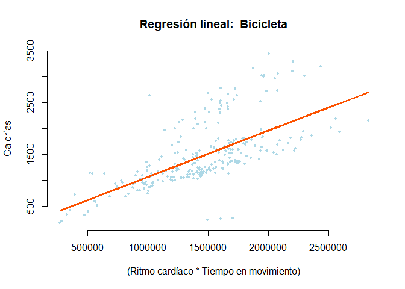

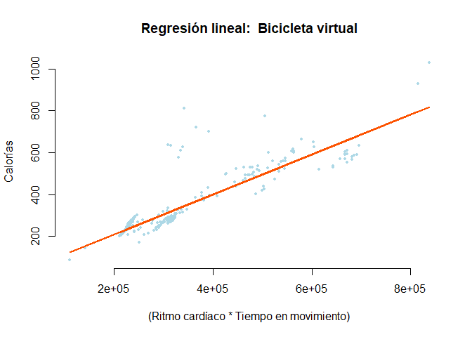

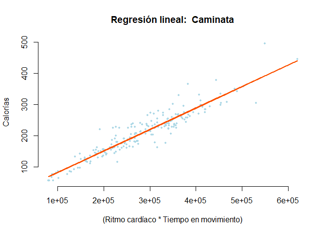

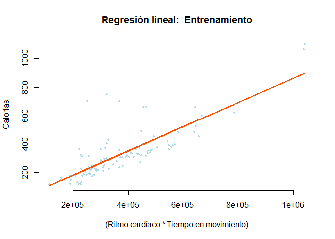

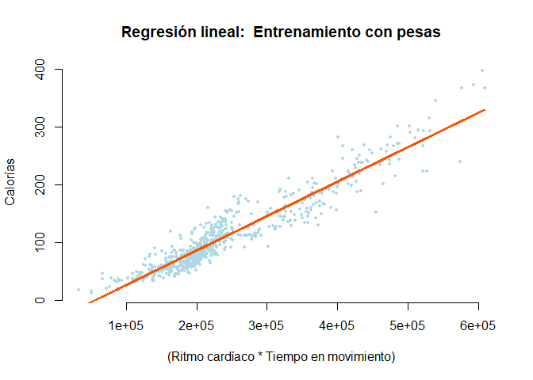

```r
for(i in levels(d$Tipo.de.actividad)){
  index <- d$Tipo.de.actividad==i & !is.na(d$Calorías)
  ratio <- period_to_seconds(d$Tiempo.en.movimiento[index]) * d$Ritmo.cardiaco.promedio[index]
  if(sum(index)>1){
    rl <- lm(d$Calorías[index] ~ ratio)
    ypred <- rl$fitted.values
    plot(ratio,
         d$Calorías[index],
         main = paste('Regresión lineal: ', i),
         xlab = '(Ritmo cardíaco * Tiempo en movimiento)',
         ylab = 'Calorías',
         pch = 19,
         cex = .5,
         col = 'light blue',
         frame = FALSE)
    lines(ratio,
          ypred,
          lwd = 2.5,
          col = "#fc5200")
    }
}
```

```r
ratio <- period_to_seconds(d$Tiempo.en.movimiento[!is.na(d$Calorías)]) * d$Ritmo.cardiaco.promedio[!is.na(d$Calorías)]
rl <- lm(d$Calorías[!is.na(d$Calorías)] ~ ratio)
summary(rl)
```

```
##
## Call:
## lm(formula = d$Calorías[!is.na(d$Calorías)] ~ ratio)
##
## Residuals:
##      Min       1Q   Median       3Q      Max
## -1432.19   -52.75   -20.78    42.53  1655.23
##
## Coefficients:
##               Estimate Std. Error t value Pr(>|t|)
## (Intercept) -9.547e+01  7.594e+00  -12.57   <2e-16 ***
## ratio        1.058e-03  1.089e-05   97.15   <2e-16 ***
## ---
## Signif. codes:  0 '***' 0.001 '**' 0.01 '*' 0.05 '.' 0.1 ' ' 1
##
## Residual standard error: 210.8 on 1508 degrees of freedom
## Multiple R-squared:  0.8622, Adjusted R-squared:  0.8621
## F-statistic:  9438 on 1 and 1508 DF,  p-value: < 2.2e-16
```

La variable *Calorías* está explicada en mayor medida por el producto de las variables *Ritmo.cardiaco.promedio* y *Tiempo.en.movimiento* ($R^{2}$ = *0.86*), por lo que imputamos el valor a los valores vacíos de la siguiente manera: se calcula la media de la división de las calorías entre el producto del tiempo de actividad por el ritmo cardíaco medio por cada tipo de actividad; posteriormente, se calcula el producto del tiempo de actividad por el ritmo cardíaco medio de las actividades de dicho tipo cuyas calorías son valores vacíos y se multiplica por el valor previamente calculado. El resultado es el valor imputado a los valores vacíos de cada actividad.

```r
for(i in levels(d$Tipo.de.actividad)){
  index <- is.na(d$Calorías) & d$Tipo.de.actividad==i
  if(sum(index)>0){
    d$Calorías[index] <- as.integer(mean(d$Calorías[d$Tipo.de.actividad==i] / (period_to_seconds(d$Tiempo.en.movimiento[d$Tipo.de.actividad==i]) * d$Ritmo.cardiaco.promedio[d$Tipo.de.actividad==i]), na.rm=TRUE) * (period_to_seconds(d$Tiempo.en.movimiento[index]) * d$Ritmo.cardiaco.promedio[index]))
  }
}
summary(d$Calorías)
```

```
##    Min. 1st Qu.  Median    Mean 3rd Qu.    Max.    NA's
##    12.0    93.5   211.0   442.2   402.5  3435.0       1
```

```r
summary(d$Tipo.de.actividad[is.na(d$Calorías)])
```

```
##               Bicicleta       Bicicleta virtual                Caminata
##                       0                       0                       0
##                 Carrera           Entrenamiento Entrenamiento con pesas
##                       0                       0                       0
##                Natación
##                       1
```

Como solo hay una actividad de tipo *Natación*, no se puede imputar las calorías de la forma anterior. Por tanto, se lo imputaremos como si fuera una actividad de tipo *Carrera*, ya que el gasto calórico por unidad de tiempo y ritmo cardíaco es similar.

```r
i <- 'Carrera'
index <- is.na(d$Calorías) & d$Tipo.de.actividad=='Natación'
d$Calorías[index] <- as.integer(mean(d$Calorías[d$Tipo.de.actividad==i] / (period_to_seconds(d$Tiempo.en.movimiento[d$Tipo.de.actividad==i]) * d$Ritmo.cardiaco.promedio[d$Tipo.de.actividad==i]), na.rm=TRUE) * (period_to_seconds(d$Tiempo.en.movimiento[index]) * d$Ritmo.cardiaco.promedio[index]))
summary(d$Calorías)
```

```
##    Min. 1st Qu.  Median    Mean 3rd Qu.    Max.
##   12.00   93.75  211.50  442.12  402.25 3435.00
```

```r
summary(d$Tipo.de.actividad[is.na(d$Calorías)])
```

```
##               Bicicleta       Bicicleta virtual                Caminata
##                       0                       0                       0
##                 Carrera           Entrenamiento Entrenamiento con pesas
##                       0                       0                       0
##                Natación
##                       0
```

# **Análisis**

## **Planificación**

Realizaremos el estudio sobre las variables *Fecha.de.la.actividad.* y *Tiempo.en.movimiento* de las actividades de tipo *Bicicleta*, *Bicicleta virtual*, *Entrenamiento con pesas*, *Entrenamiento* y *Caminata*.

```r
b <- d$Tipo.de.actividad == 'Bicicleta'
v <- d$Tipo.de.actividad == 'Bicicleta virtual'
p <- d$Tipo.de.actividad == 'Entrenamiento con pesas'
e <- d$Tipo.de.actividad == 'Entrenamiento'
c <- d$Tipo.de.actividad == 'Caminata'
```

## **Normalidad y homocedasticidad**

### *Fecha.de.la.actividad*

Vamos a analizar si la distribución de las actividades por cada tipo a lo largo del tiempo sigue una distribución normal. Las de tipo *Caminata* no las estudiaremos en este apartado debido a su corta acotación en el tiempo.

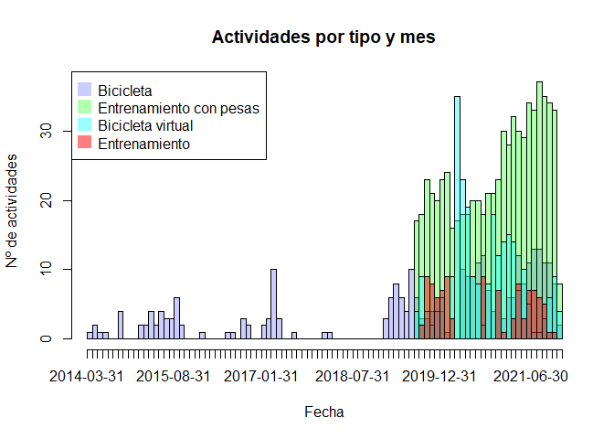

```r
xmin = min(c(min(d$Fecha.de.la.actividad[b]),
         min(d$Fecha.de.la.actividad[v]),
         min(d$Fecha.de.la.actividad[p]),
         min(d$Fecha.de.la.actividad[e])))
xmax = max(c(max(d$Fecha.de.la.actividad[b]),
         max(d$Fecha.de.la.actividad[v]),
         max(d$Fecha.de.la.actividad[p]),
         max(d$Fecha.de.la.actividad[e])))
ymax = max(c(max(aggregate(d$Fecha.de.la.actividad[b], by=list(month=as.numeric(format(d$Fecha.de.la.actividad[b], "%Y%m"))), FUN=length)['x']),
             max(aggregate(d$Fecha.de.la.actividad[v], by=list(month=as.numeric(format(d$Fecha.de.la.actividad[v], "%Y%m"))), FUN=length)['x']),
             max(aggregate(d$Fecha.de.la.actividad[p], by=list(month=as.numeric(format(d$Fecha.de.la.actividad[p], "%Y%m"))), FUN=length)['x']),
             max(aggregate(d$Fecha.de.la.actividad[e], by=list(month=as.numeric(format(d$Fecha.de.la.actividad[e], "%Y%m"))), FUN=length)['x'])))

hist(d$Fecha.de.la.actividad[b],
     breaks = 'months',
     main='Actividades por tipo y mes',
     col=rgb(0,0,1,0.2),
     xlim=c(xmin, xmax), ylim=c(0,ymax),
     xlab='Fecha',
     ylab='Nº de actividades',
     freq=TRUE);par(new=TRUE)
hist(d$Fecha.de.la.actividad[p],
     breaks = 'months',
     main='',
     col=rgb(0,1,0,0.3),
     xlim=c(xmin, xmax), ylim=c(0,ymax),
     xaxt='n',
     xlab='',
     ylab='',
     freq=TRUE);par(new=TRUE)
hist(d$Fecha.de.la.actividad[v],
     breaks = 'months',
     main='',
     col=rgb(0,1,1,0.4),
     xlim=c(xmin, xmax), ylim=c(0,ymax),
     xaxt='n',
     xlab='',
     ylab='',
     freq=TRUE);par(new=TRUE)
hist(d$Fecha.de.la.actividad[e],
     breaks = 'months',
     main='',
     col=rgb(1,0,0,0.5),
     xlim=c(xmin, xmax), ylim=c(0,ymax),
     xaxt='n',
     xlab='',
     ylab='',
     freq=TRUE);par(new=TRUE)
legend("topleft", legend=c("Bicicleta", "Entrenamiento con pesas", "Bicicleta virtual", "Entrenamiento"), col=c(rgb(0,0,1,0.2), rgb(0,1,0,0.3), rgb(0,1,1,0.4), rgb(1,0,0,0.5)), pt.cex=2, pch=15 )
```

Analizaremos la normalidad caso por caso.

#### **Normalidad**

##### *Bicicleta*

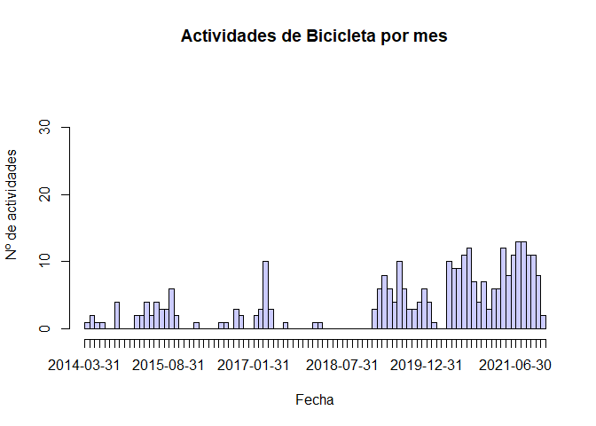

```r
hist(d$Fecha.de.la.actividad[b],
     breaks = 'months',
     main='Actividades de Bicicleta por mes',
     col=rgb(0,0,1,0.2),
     xlim=c(xmin, xmax), ylim=c(0,ymax),
     xlab='Fecha',
     ylab='Nº de actividades',
     freq=TRUE)
```

Para estudiar la normalidad, emplearemos el *test de Lilliefors*. Consiste en formular el siguiente contraste de hipótesis:

**H<sub>0</sub>**: *Los datos siguen una distribución normal.*

**H<sub>1</sub>**: *Los datos **no*** *siguen una distribución normal.*

Para ello, tendremos que aplicar el test sobre la distribución temporal de las actividades según su tipo de la siguiente manera:

```r
nortest::lillie.test(as.numeric(d$Fecha.de.la.actividad[b])/24)
```

```
##
##  Lilliefors (Kolmogorov-Smirnov) normality test
##
## data:  as.numeric(d$Fecha.de.la.actividad[b])/24
## D = 0.1851, p-value < 2.2e-16
```

Como *p-valor = 0*, se puede rechazar con un 95% de confianza la hipótesis nula. Por lo tanto, **la distribución temporal de las actividades de tipo *Bicicleta* no sigue una distribución normal.**

##### *Bicicleta virtual*

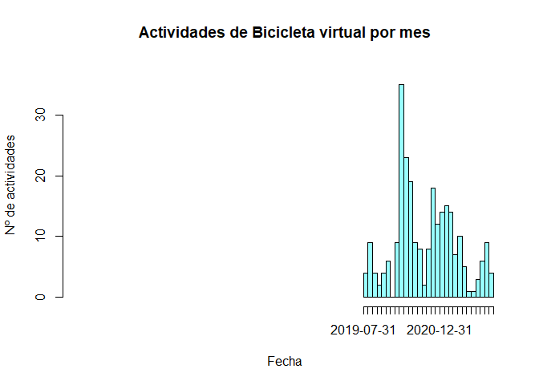

```r
hist(d$Fecha.de.la.actividad[v],
     breaks = 'months',
     main='Actividades de Bicicleta virtual por mes',
     col=rgb(0,1,1,0.4),
     xlim=c(xmin, xmax), ylim=c(0,ymax),
     xlab='Fecha',
     ylab='Nº de actividades',
     freq=TRUE)
```

```r
nortest::lillie.test(as.numeric(d$Fecha.de.la.actividad[v])/24)
```

```
##
##  Lilliefors (Kolmogorov-Smirnov) normality test
##
## data:  as.numeric(d$Fecha.de.la.actividad[v])/24
## D = 0.10703, p-value = 1.189e-07
```

Como *p-valor = 0*, se puede rechazar con un 95% de confianza la hipótesis nula. Por lo tanto, **la distribución temporal de las actividades de tipo *Bicicleta virtual* no sigue una distribución normal.**

##### *Entrenamiento con pesas*

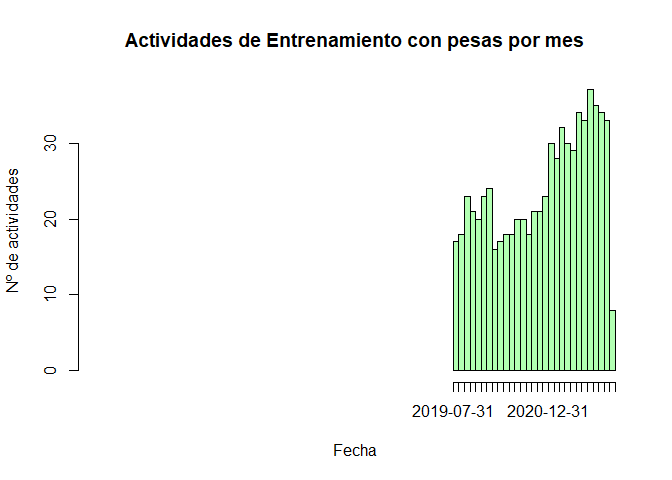

```r
hist(d$Fecha.de.la.actividad[p],
     breaks = 'months',
     main='Actividades de Entrenamiento con pesas por mes',
     col=rgb(0,1,0,0.3),
     xlim=c(xmin, xmax), ylim=c(0,ymax),
     xlab='Fecha',
     ylab='Nº de actividades',
     freq=TRUE)
```

```r
nortest::lillie.test(as.numeric(d$Fecha.de.la.actividad[p])/24)
```

```
##
##  Lilliefors (Kolmogorov-Smirnov) normality test
##
## data:  as.numeric(d$Fecha.de.la.actividad[p])/24
## D = 0.081551, p-value = 5.677e-12
```

Como *p-valor = 0*, se puede rechazar con un 95% de confianza la hipótesis nula. Por lo tanto, **la distribución temporal de las actividades de tipo *Entrenamiento con pesas* no sigue una distribución normal**

##### *Entrenamiento*

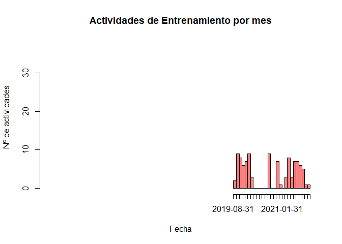

```r
hist(d$Fecha.de.la.actividad[e],
     breaks = 'months',
     main='Actividades de Entrenamiento por mes',
     col=rgb(1,0,0,0.5),
     xlim=c(xmin, xmax), ylim=c(0,ymax),
     xlab='Fecha',
     ylab='Nº de actividades',
     freq=TRUE)
```

```r
nortest::lillie.test(as.numeric(d$Fecha.de.la.actividad[e])/24)
```

```
##
##  Lilliefors (Kolmogorov-Smirnov) normality test
##
## data:  as.numeric(d$Fecha.de.la.actividad[e])/24
## D = 0.20202, p-value = 4.594e-11
```

Como *p-valor = 0*, se puede rechazar con un 95% de confianza la hipótesis nula. Por lo tanto, **la distribución temporal de las actividades de tipo *Entrenamiento* no sigue una distribución normal.**

#### **Homocedasticidad**

##### *Bicicleta* & *Bicicleta virtual*

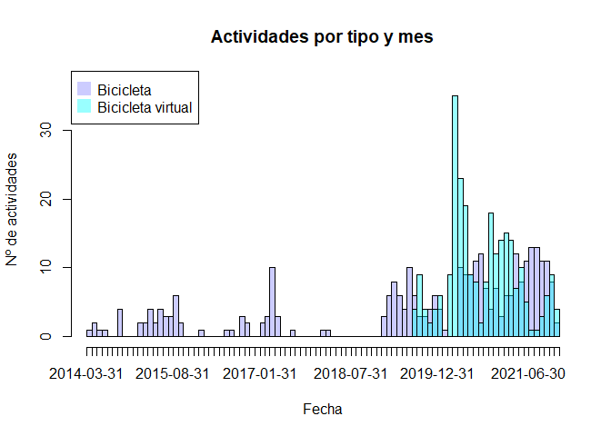

```r
hist(d$Fecha.de.la.actividad[b],
     breaks = 'months',
     main='Actividades por tipo y mes',
     col=rgb(0,0,1,0.2),
     xlim=c(xmin, xmax), ylim=c(0,ymax),
     xlab='Fecha',
     ylab='Nº de actividades',
     freq=TRUE);par(new=TRUE)
hist(d$Fecha.de.la.actividad[v],
     breaks = 'months',
     main='',
     col=rgb(0,1,1,0.4),
     xlim=c(xmin, xmax), ylim=c(0,ymax),
     xaxt='n',
     xlab='',
     ylab='',
     freq=TRUE);par(new=TRUE)
legend("topleft", legend=c("Bicicleta", "Bicicleta virtual"), col=c(rgb(0,0,1,0.2), rgb(0,1,1,0.4)), pt.cex=2, pch=15)
```

Para estudiar la homocedasticidad, emplearemos el *F test*. Consiste en formular el siguiente contraste de hipótesis:

**H<sub>0</sub>**: *$\sigma$$^{2}$<sub>Bicicleta</sub> = $\sigma$$^{2}$<sub>BicicletaVirtual</sub>*

**H<sub>1</sub>**: *$\sigma$$^{2}$<sub>Bicicleta</sub> $\not=$ $\sigma$$^{2}$<sub>BicicletaVirtual</sub>*

```r
var.test(d$Fecha.de.la.actividad[b], d$Fecha.de.la.actividad[v])
```

```
##
##  F test to compare two variances
##
## data:  d$Fecha.de.la.actividad[b] and d$Fecha.de.la.actividad[v]
## F = 13.772, num df = 302, denom df = 260, p-value < 2.2e-16
## alternative hypothesis: true ratio of variances is not equal to 1
## 95 percent confidence interval:
##  10.87622 17.40119
## sample estimates:
## ratio of variances
##           13.77153
```

Como *p-valor = 0*, se puede rechazar con un 95% de confianza la hipótesis nula. Por lo tanto, **las distribuciones temporales de las actividades *Bicicleta* y *Bicicleta virtual* tienen varianzas distintas.**

##### *Bicicleta virtual* & *Entrenamiento con pesas*

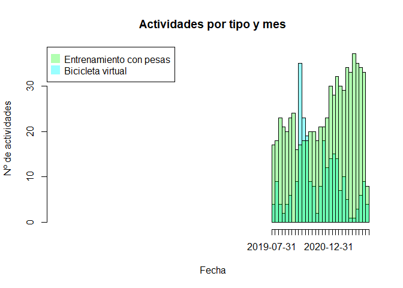

```r
hist(d$Fecha.de.la.actividad[v],
     breaks = 'months',
     main='Actividades por tipo y mes',
     col=rgb(0,1,1,0.4),
     xlim=c(xmin, xmax), ylim=c(0,ymax),
     xlab='Fecha',
     ylab='Nº de actividades',
     freq=TRUE);par(new=TRUE)
hist(d$Fecha.de.la.actividad[p],
     breaks = 'months',
     main='',
     col=rgb(0,1,0,0.3),
     xlim=c(xmin, xmax), ylim=c(0,ymax),
     xaxt='n',
     xlab='',
     ylab='',
     freq=TRUE);par(new=TRUE)
legend("topleft", legend=c("Entrenamiento con pesas", "Bicicleta virtual"), col=c(rgb(0,1,0,0.3), rgb(0,1,1,0.4)), pt.cex=2, pch=15 )
```

```r
var.test(d$Fecha.de.la.actividad[v], d$Fecha.de.la.actividad[p])
```

```
##
##  F test to compare two variances
##
## data:  d$Fecha.de.la.actividad[v] and d$Fecha.de.la.actividad[p]
## F = 0.68724, num df = 260, denom df = 700, p-value = 0.0004239
## alternative hypothesis: true ratio of variances is not equal to 1
## 95 percent confidence interval:
##  0.5643911 0.8447693
## sample estimates:
## ratio of variances
##          0.6872417
```

Como *p-valor < 0.05*, se puede rechazar con un 95% de confianza la hipótesis nula. Por lo tanto, **las distribuciones temporales de las actividades *Bicicleta virtual* y *Entrenamiento con pesas* tienen varianzas distintas.**

##### *Entrenamiento con pesas* & *Entrenamiento*

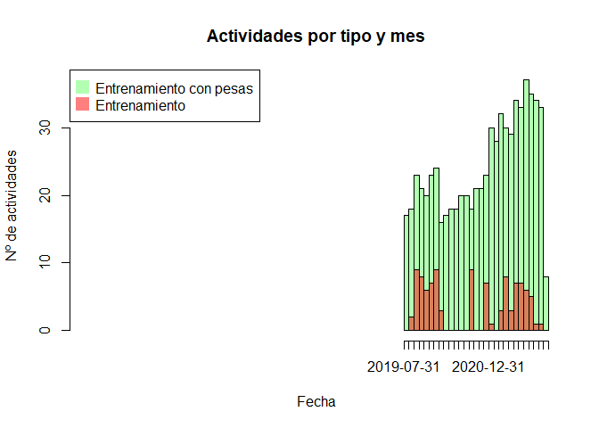

```r
hist(d$Fecha.de.la.actividad[p],
     breaks = 'months',
     main='Actividades por tipo y mes',
     col=rgb(0,1,0,0.3),
     xlim=c(xmin, xmax), ylim=c(0,ymax),
     xlab='Fecha',
     ylab='Nº de actividades',
     freq=TRUE);par(new=TRUE)
hist(d$Fecha.de.la.actividad[e],
     breaks = 'months',
     main='',
     col=rgb(1,0,0,0.5),
     xlim=c(xmin, xmax), ylim=c(0,ymax),
     xaxt='n',
     xlab='',
     ylab='',
     freq=TRUE);par(new=TRUE)
legend("topleft", legend=c("Entrenamiento con pesas", "Entrenamiento"), col=c(rgb(0,1,0,0.3), rgb(1,0,0,0.5)), pt.cex=2, pch=15 )
```

```r
var.test(d$Fecha.de.la.actividad[p], d$Fecha.de.la.actividad[e])
```

```
##
##  F test to compare two variances
##
## data:  d$Fecha.de.la.actividad[p] and d$Fecha.de.la.actividad[e]
## F = 0.92279, num df = 700, denom df = 101, p-value = 0.5645
## alternative hypothesis: true ratio of variances is not equal to 1
## 95 percent confidence interval:
##  0.6748172 1.2207150
## sample estimates:
## ratio of variances
##          0.9227921
```

Como *p-valor > 0.05*, no se puede rechazar la hipótesis nula. Por lo tanto, **las distribuciones temporales de las actividades *Entrenamiento con pesas* y *Entrenamiento* tienen varianzas iguales.**

### *Tiempo.en.movimiento*

Para estudiar esta variable, utilizaremos las actividades de tipo *Bicicleta*, *Bicicleta virtual*, *Entrenamiento*, *Entrenamiento con pesas* y *Caminata*.

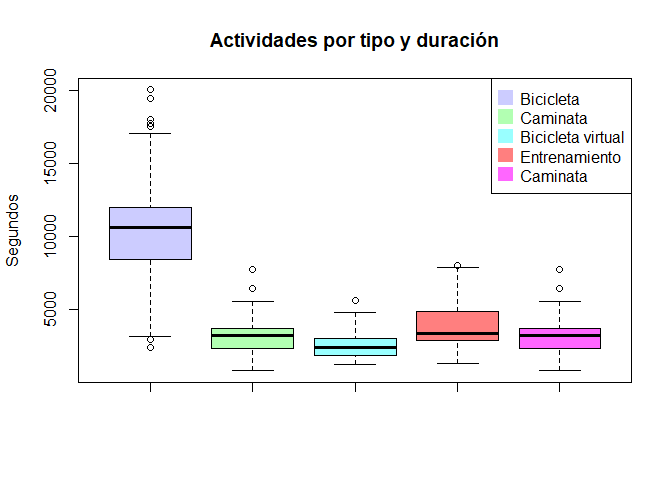

```r
boxplot(period_to_seconds(d$Tiempo.en.movimiento[b]),
        period_to_seconds(d$Tiempo.en.movimiento[c]),
        period_to_seconds(d$Tiempo.en.movimiento[v]),
        period_to_seconds(d$Tiempo.en.movimiento[e]),
        period_to_seconds(d$Tiempo.en.movimiento[c]),
     main='Actividades por tipo y duración',
     col=c(rgb(0,0,1,0.2), rgb(0,1,0,0.3), rgb(0,1,1,0.4), rgb(1,0,0,0.5), rgb(1,0,1,0.6)),
     ylab='Segundos')
legend("topright", legend=c("Bicicleta", "Caminata", "Bicicleta virtual", "Entrenamiento", "Caminata"), col=c(rgb(0,0,1,0.2), rgb(0,1,0,0.3), rgb(0,1,1,0.4), rgb(1,0,0,0.5), rgb(1,0,1,0.6)), pt.cex=2, pch=15 )
```

Analizaremos la normalidad caso por caso.

#### **Normalidad**

##### *Bicicleta*

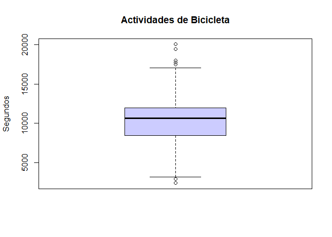

```r
boxplot(period_to_seconds(d$Tiempo.en.movimiento[b]),
     main='Actividades de Bicicleta',
     col=rgb(0,0,1,0.2),
     ylab='Segundos')
```

```r
nortest::lillie.test(period_to_seconds(d$Tiempo.en.movimiento[b]))
```

```
##
##  Lilliefors (Kolmogorov-Smirnov) normality test
##
## data:  period_to_seconds(d$Tiempo.en.movimiento[b])
## D = 0.066369, p-value = 0.002615
```

Como *p-valor < 0.05*, se puede rechazar con un 95% de confianza la hipótesis nula. Por lo tanto, **la distribución del tiempo efectivo de las actividades de tipo *Bicicleta* no sigue una distribución normal.**

##### *Bicicleta virtual*

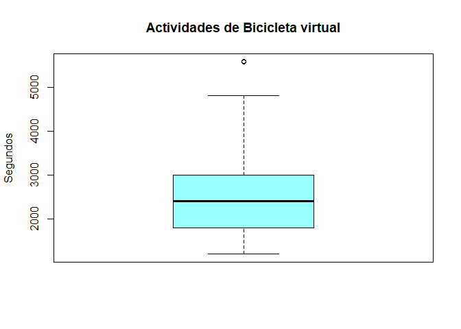

```r
boxplot(period_to_seconds(d$Tiempo.en.movimiento[v]),
     main='Actividades de Bicicleta virtual',
     col=rgb(0,1,1,0.4),
     ylab='Segundos')
```

```r
nortest::lillie.test(period_to_seconds(d$Tiempo.en.movimiento[v]))
```

```
##
##  Lilliefors (Kolmogorov-Smirnov) normality test
##
## data:  period_to_seconds(d$Tiempo.en.movimiento[v])
## D = 0.30682, p-value < 2.2e-16
```

Como *p-valor = 0*, se puede rechazar con un 95% de confianza la hipótesis nula. Por lo tanto, **la distribución del tiempo efectivo de las actividades de tipo *Bicicleta virtual* no sigue una distribución normal.**

##### *Entrenamiento con pesas*

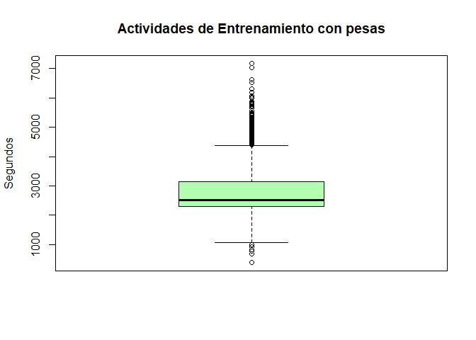

```r
boxplot(period_to_seconds(d$Tiempo.en.movimiento[p]),
     main='Actividades de Entrenamiento con pesas',
     col=rgb(0,1,0,0.3),
     ylab='Segundos')
```

```r
nortest::lillie.test(period_to_seconds(d$Tiempo.en.movimiento[p]))
```

```
##
##  Lilliefors (Kolmogorov-Smirnov) normality test
##
## data:  period_to_seconds(d$Tiempo.en.movimiento[p])
## D = 0.23184, p-value < 2.2e-16
```

Como *p-valor = 0*, se puede rechazar con un 95% de confianza la hipótesis nula. Por lo tanto, **la distribución del tiempo efectivo de las actividades de tipo *Entrenamiento con pesas* no sigue una distribución normal**

##### *Entrenamiento*

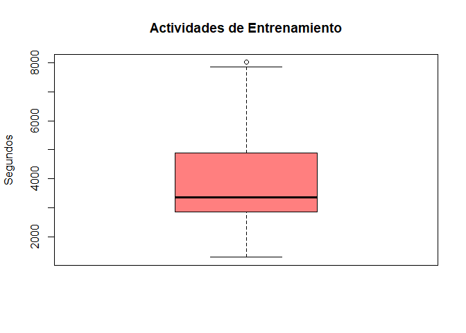

```r
boxplot(period_to_seconds(d$Tiempo.en.movimiento[e]),
     main='Actividades de Entrenamiento',
     col=rgb(1,0,0,0.5),
     ylab='Segundos')
```

```r
nortest::lillie.test(period_to_seconds(d$Tiempo.en.movimiento[e]))
```

```
##
##  Lilliefors (Kolmogorov-Smirnov) normality test
##
## data:  period_to_seconds(d$Tiempo.en.movimiento[e])
## D = 0.13963, p-value = 4.305e-05
```

Como *p-valor = 0*, se puede rechazar con un 95% de confianza la hipótesis nula. Por lo tanto, **la distribución del tiempo efectivo de las actividades de tipo *Entrenamiento* no sigue una distribución normal.**

##### *Caminata*

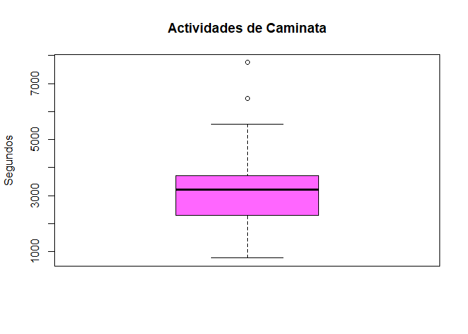

```r
boxplot(period_to_seconds(d$Tiempo.en.movimiento[c]),
     main='Actividades de Caminata',
     col=rgb(1,0,1,0.6),
     ylab='Segundos')
```

```r
nortest::lillie.test(period_to_seconds(d$Tiempo.en.movimiento[c]))
```

```
##
##  Lilliefors (Kolmogorov-Smirnov) normality test
##
## data:  period_to_seconds(d$Tiempo.en.movimiento[c])
## D = 0.066336, p-value = 0.03991
```

#### **Homocedasticidad**

##### *Bicicleta* & *Bicicleta virtual*

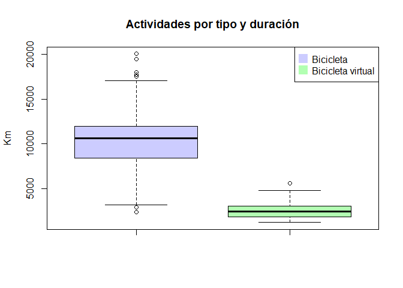

```r
boxplot(period_to_seconds(d$Tiempo.en.movimiento[b]), period_to_seconds(d$Tiempo.en.movimiento[v]),
     main='Actividades por tipo y duración',
     col=c(rgb(0,0,1,0.2), rgb(0,1,0,0.3)),
     ylab='Km')
legend("topright", legend=c("Bicicleta", "Bicicleta virtual"), col=c(rgb(0,0,1,0.2), rgb(0,1,0,0.3)), pt.cex=2, pch=15 )
```

```r
var.test(period_to_seconds(d$Tiempo.en.movimiento[b]), period_to_seconds(d$Tiempo.en.movimiento[v]))
```

```
##
##  F test to compare two variances
##
## data:  period_to_seconds(d$Tiempo.en.movimiento[b]) and period_to_seconds(d$Tiempo.en.movimiento[v])
## F = 10.383, num df = 302, denom df = 260, p-value < 2.2e-16
## alternative hypothesis: true ratio of variances is not equal to 1
## 95 percent confidence interval:
##   8.199811 13.119129
## sample estimates:
## ratio of variances
##           10.38265
```

Como *p-valor = 0*, se puede rechazar con un 95% de confianza la hipótesis nula. Por lo tanto, **las distribuciones del tiempo efectivo de las actividades *Bicicleta* y *Bicicleta virtual* tienen varianzas distintas.**

##### *Bicicleta virtual* & *Caminata*

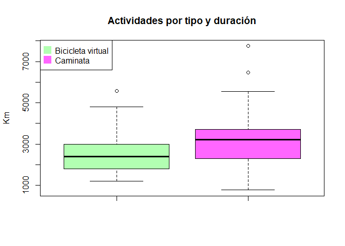

```r
boxplot(period_to_seconds(d$Tiempo.en.movimiento[v]), period_to_seconds(d$Tiempo.en.movimiento[c]),
     main='Actividades por tipo y duración',
     col=c(rgb(0,1,0,0.3), rgb(1,0,1,0.6)),
     ylab='Km')
legend("topleft", legend=c("Bicicleta virtual", "Caminata"), col=c(rgb(0,1,0,0.3), rgb(1,0,1,0.6)), pt.cex=2, pch=15 )
```

```r
var.test(period_to_seconds(d$Tiempo.en.movimiento[v]), period_to_seconds(d$Tiempo.en.movimiento[c]))
```

```
##
##  F test to compare two variances
##
## data:  period_to_seconds(d$Tiempo.en.movimiento[v]) and period_to_seconds(d$Tiempo.en.movimiento[c])
## F = 0.78384, num df = 260, denom df = 190, p-value = 0.06897
## alternative hypothesis: true ratio of variances is not equal to 1
## 95 percent confidence interval:
##  0.5995519 1.0191057
## sample estimates:
## ratio of variances
##          0.7838385
```

Como *p-valor > 0.05*, no se puede rechazar con un 95% de confianza la hipótesis nula. Por lo tanto, **las distribuciones del tiempo efectivo de las actividades *Bicicleta virtual* y *Caminata* tienen varianzas iguales.**

##### *Entrenamiento con pesas* & *Caminata*

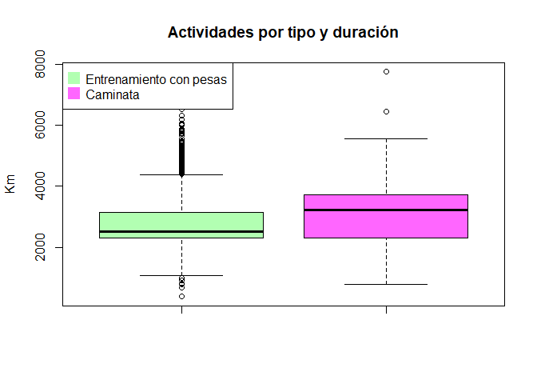

```r
boxplot(period_to_seconds(d$Tiempo.en.movimiento[p]), period_to_seconds(d$Tiempo.en.movimiento[c]),
     main='Actividades por tipo y duración',
     col=c(rgb(0,1,0,0.3), rgb(1,0,1,0.6)),
     ylab='Km')
legend("topleft", legend=c("Entrenamiento con pesas", "Caminata"), col=c(rgb(0,1,0,0.3), rgb(1,0,1,0.6)), pt.cex=2, pch=15 )
```

```r
var.test(period_to_seconds(d$Tiempo.en.movimiento[p]), period_to_seconds(d$Tiempo.en.movimiento[c]))
```

```
##
##  F test to compare two variances
##
## data:  period_to_seconds(d$Tiempo.en.movimiento[p]) and period_to_seconds(d$Tiempo.en.movimiento[c])
## F = 1.0471, num df = 700, denom df = 190, p-value = 0.7088
## alternative hypothesis: true ratio of variances is not equal to 1
## 95 percent confidence interval:
##  0.8279776 1.3044578
## sample estimates:
## ratio of variances
##           1.047074
```

Como *p-valor > 0.05*, no se puede rechazar la hipótesis nula. Por lo tanto, **las distribuciones del tiempo efectivo de las actividades *Entrenamiento con pesas* y *Caminata* tienen varianzas iguales.**

# **Resumen de las pruebas estadísticas**

Se han realizado las siguientes pruebas estadísticas con los datos:

- **Test de correlación de *Pearson*** y **regresión lineal**: La datos de la variable *calorías* no proceden directamente de ningún sensor, sino que se obtienen mediante un cálculo desconocido realizado por el ciclocomputador en base a otras variables. Para realizar la imputación de los valores vacíos de *Calorías*, hemos realizado un test de correlación entre ésta y el producto de dos variables: *Ritmo.cardíaco.promedio* y *Tiempo.en.movimiento*. El resultado mostraba un alto grado de correlación, por lo que construimos un modelo de regresión lineal para estimar e imputar los valores vacíos de *Calorías*.

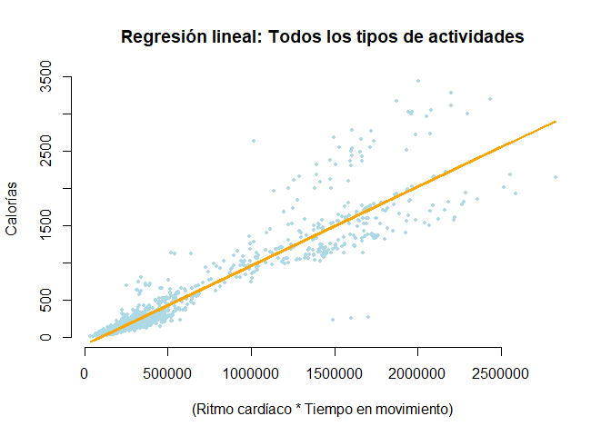

```r
ratio <- period_to_seconds(d$Tiempo.en.movimiento[!is.na(d$Calorías)]) * d$Ritmo.cardiaco.promedio[!is.na(d$Calorías)]
rl <- lm(d$Calorías[!is.na(d$Calorías)] ~ ratio)
ypred <- rl$fitted.values
plot(ratio,
     d$Calorías[!is.na(d$Calorías)],
     main = paste('Regresión lineal: Todos los tipos de actividades'),
     xlab = '(Ritmo cardíaco * Tiempo en movimiento)',
     ylab = 'Calorías',
     pch = 19,
     cex = .5,
     col = 'light blue',
     frame = FALSE)
lines(ratio,
      ypred,
      lwd = 2,
      col = 'orange')
```

- **Test de *Lilliefors***: Para estudiar si la distribución de las fechas y la duración de las variables seguía una distribución normal, hemos aplicado el test de normalidad de *Lilliefors* para las actividades de cada tipo, resultando en que ninguna de ellas seguía una distribución normal.

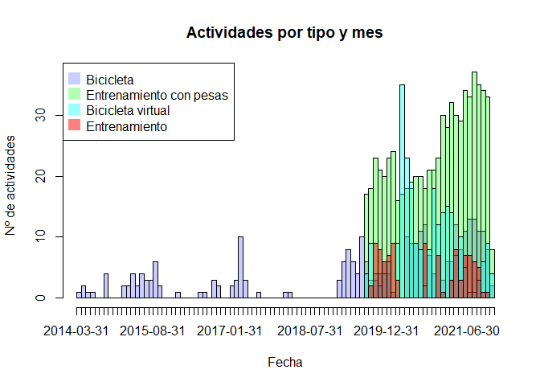

```r
hist(d$Fecha.de.la.actividad[b],
     breaks = 'months',
     main='Actividades por tipo y mes',
     col=rgb(0,0,1,0.2),
     xlim=c(xmin, xmax), ylim=c(0,ymax),
     xlab='Fecha',
     ylab='Nº de actividades',
     freq=TRUE);par(new=TRUE)
hist(d$Fecha.de.la.actividad[p],
     breaks = 'months',
     main='',
     col=rgb(0,1,0,0.3),
     xlim=c(xmin, xmax), ylim=c(0,ymax),
     xaxt='n',
     xlab='',
     ylab='',
     freq=TRUE);par(new=TRUE)
hist(d$Fecha.de.la.actividad[v],
     breaks = 'months',
     main='',
     col=rgb(0,1,1,0.4),
     xlim=c(xmin, xmax), ylim=c(0,ymax),
     xaxt='n',
     xlab='',
     ylab='',
     freq=TRUE);par(new=TRUE)
hist(d$Fecha.de.la.actividad[e],
     breaks = 'months',
     main='',
     col=rgb(1,0,0,0.5),
     xlim=c(xmin, xmax), ylim=c(0,ymax),
     xaxt='n',
     xlab='',
     ylab='',
     freq=TRUE);par(new=TRUE)
legend("topleft", legend=c("Bicicleta", "Entrenamiento con pesas", "Bicicleta virtual", "Entrenamiento"), col=c(rgb(0,0,1,0.2), rgb(0,1,0,0.3), rgb(0,1,1,0.4), rgb(1,0,0,0.5)), pt.cex=2, pch=15 )
```

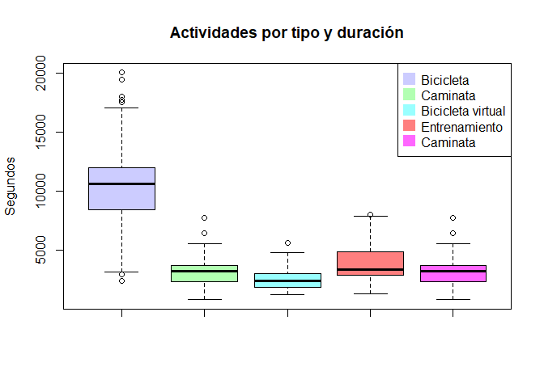

```r
boxplot(period_to_seconds(d$Tiempo.en.movimiento[b]),
        period_to_seconds(d$Tiempo.en.movimiento[c]),
        period_to_seconds(d$Tiempo.en.movimiento[v]),
        period_to_seconds(d$Tiempo.en.movimiento[e]),
        period_to_seconds(d$Tiempo.en.movimiento[c]),
     main='Actividades por tipo y duración',
     col=c(rgb(0,0,1,0.2), rgb(0,1,0,0.3), rgb(0,1,1,0.4), rgb(1,0,0,0.5), rgb(1,0,1,0.6)),
     ylab='Segundos')
legend("topright", legend=c("Bicicleta", "Caminata", "Bicicleta virtual", "Entrenamiento", "Caminata"), col=c(rgb(0,0,1,0.2), rgb(0,1,0,0.3), rgb(0,1,1,0.4), rgb(1,0,0,0.5), rgb(1,0,1,0.6)), pt.cex=2, pch=15 )
```

- **F test**: Para analizar la homogeneidad de las varianzas de las distribuciones de las fechas y la duración de las actividades de dos tipos distintos, hemos realizado este test de homocedasticidad para varios pares de diferentes tipos de actividades. Hemos hayado que las varianzas son iguales para las distribuciones temporales de las actividades de tipo *Entrenamiento con pesas* y *Entrenamiento*, y las distribucciones del tiempo efectivo de las de tipo *Entrenamiento con pesas* y *Caminata*, así como las de *Bicicleta virtual* y *Caminata*

```r
# F test entre las actividades de Entrenamiento con pesas y Entrenamiento por fecha
var.test(d$Fecha.de.la.actividad[p], d$Fecha.de.la.actividad[e])
```

```
##
##  F test to compare two variances
##
## data:  d$Fecha.de.la.actividad[p] and d$Fecha.de.la.actividad[e]
## F = 0.92279, num df = 700, denom df = 101, p-value = 0.5645
## alternative hypothesis: true ratio of variances is not equal to 1
## 95 percent confidence interval:
##  0.6748172 1.2207150
## sample estimates:
## ratio of variances
##          0.9227921
```

```r
# F test entre las actividades de Entrenamiento con pesas y Caminata por tiempo efectivo
var.test(period_to_seconds(d$Tiempo.en.movimiento[p]), period_to_seconds(d$Tiempo.en.movimiento[c]))
```

```
##
##  F test to compare two variances
##
## data:  period_to_seconds(d$Tiempo.en.movimiento[p]) and period_to_seconds(d$Tiempo.en.movimiento[c])
## F = 1.0471, num df = 700, denom df = 190, p-value = 0.7088
## alternative hypothesis: true ratio of variances is not equal to 1
## 95 percent confidence interval:
##  0.8279776 1.3044578
## sample estimates:
## ratio of variances
##           1.047074
```

```r
# F test entre las actividades de Bicicleta virtual y Caminata por tiempo efectivo
var.test(period_to_seconds(d$Tiempo.en.movimiento[v]), period_to_seconds(d$Tiempo.en.movimiento[c]))
```

```
##
##  F test to compare two variances
##
## data:  period_to_seconds(d$Tiempo.en.movimiento[v]) and period_to_seconds(d$Tiempo.en.movimiento[c])
## F = 0.78384, num df = 260, denom df = 190, p-value = 0.06897
## alternative hypothesis: true ratio of variances is not equal to 1
## 95 percent confidence interval:
##  0.5995519 1.0191057
## sample estimates:
## ratio of variances
##          0.7838385
```

# **Guardar el dataset**

```r
write.csv(d,"ActivitiesClean.csv", row.names = FALSE)
```